# MCSMoore_Pharma

### Introduction

The project is to use a predictive model focusing on understanding the future of business. Applying Monte Carlo method, the model will predict financial performance metrics in multiple time periods (like profitability, cash flow, sales and others). The model is commonly used in financial planning & budgeting.

Tool: Python. Thought Excel spreadsheet models are more practical and preferred by most finance professionals.

### Define problem

ABC Company has a new-product development decision which involves a lot of uncertainty. The company is interested in evaluating the risk associated with the project and need to answer 3 questions as follows:

1. What is the risk that the net present value (NPV) over the five years will not be positive?
2. What are the chances that the product will show a positive cumulative net profit in the third year?
3. In the fifth year, what minimum amount of cumulative profit are we likely to achieve with a probability of at least 90%?

### Import library

```python
import numpy as np
import pandas as pd
import statistics
import random
import matplotlib.pyplot as plt
%matplotlib inline
```

### Code

```python
discount_rate = 0.09
unit_sales = 130
unit_cost = 40
unit_margin = unit_sales - unit_cost
market_size_mean = 2000000
market_size_sd = 40000
clinical_trial_cost_mean = 150000000
clinical_trial_cost_sd = 30000000
rd_cost_lower = 600000000
rd_cost_upper = 800000000
annual_mk_growth_min = .02
annual_mk_growth_mode = .03
annual_mk_growth_max = .06
share_growth_min = .15
share_growth_mode = .2
share_growth_max = .25
iteration = 1000
project_year = 5
def project ():
    outputs = []
    for i in range(iteration):
        rd_cost = np.random.uniform(rd_cost_lower,rd_cost_upper)
        clinical_trial_cost = np.random.normal(clinical_trial_cost_mean,clinical_trial_cost_sd)
        project_cost = round((rd_cost + clinical_trial_cost)/1000000)
        share = .08
        mksize = np.random.normal(market_size_mean,market_size_sd)
        share_growth = list(np.random.triangular(share_growth_min,share_growth_mode,share_growth_max,project_year))
        annual_mk_growth = list(np.random.triangular(annual_mk_growth_min,annual_mk_growth_mode,annual_mk_growth_max,project_year))
        yearly_cum_profit = []
        cumulated_profit = 0 - project_cost
        npv_profit = 0
        year = 0
        while year < project_year:
            profit = round((share * mksize *  unit_margin * 12)/1000000)
            cumulated_profit = cumulated_profit + profit
            yearly_cum_profit.append(cumulated_profit)
            npv_profit = npv_profit + round(profit/(1+discount_rate)**(year+1))
            share = share * (1+share_growth[year])
            mksize = mksize * (1+ annual_mk_growth[year])
            year += 1
        npv_project = round((npv_profit - project_cost))
        yearly_cum_profit.append(npv_project)
        outputs.append(yearly_cum_profit)
    return outputs
```

### Data table

```python
df = pd.DataFrame(project(), columns = ['year1','year2','year3','year4','year5','Total_NPV'])
df.head()
```

|  | year1 | year2 | year3 | year4 | year5 | Total_NPV |
| --- | --- | --- | --- | --- | --- | --- |
| 0 | -704 | -500 | -251 | 71 | 476 | 137 |
| 1 | -614 | -401 | -137 | 194 | 607 | 257 |
| 2 | -786 | -567 | -291 | 55 | 497 | 128 |
| 3 | -572 | -370 | -119 | 194 | 570 | 244 |
| 4 | -800 | -587 | -328 | -6 | 398 | 56 |

```python
df.describe(percentiles=[.95, .75, .5, .25, .05])
```

|  | year1 | year2 | year3 | year4 | year5 | Total_NPV |
| --- | --- | --- | --- | --- | --- | --- |
| count | 1000.000000 | 1000.000000 | 1000.000000 | 1000.000000 | 1000.000000 | 1000.000000 |
| mean | -674.587000 | -459.499000 | -191.935000 | 140.972000 | 555.048000 | 203.761000 |
| std | 66.202214 | 66.810266 | 68.435197 | 72.333224 | 80.050858 | 73.789327 |
| min | -837.000000 | -613.000000 | -365.000000 | -63.000000 | 297.000000 | -16.000000 |
| 5% | -782.000000 | -567.000000 | -302.000000 | 25.950000 | 427.950000 | 86.950000 |
| 25% | -725.000000 | -511.000000 | -244.000000 | 85.750000 | 495.750000 | 148.000000 |
| 50% | -674.500000 | -459.000000 | -191.000000 | 141.000000 | 554.500000 | 203.500000 |
| 75% | -625.000000 | -409.000000 | -140.000000 | 195.000000 | 615.250000 | 259.000000 |
| 95% | -568.000000 | -351.000000 | -80.000000 | 259.100000 | 690.000000 | 326.000000 |
| max | -500.000000 | -279.000000 | -3.000000 | 333.000000 | 749.000000 | 392.000000 |

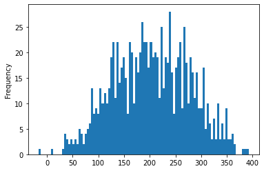

```python
df['Total_NPV'].plot.hist(bins=100)
# df['Total_NPV'].plot.kde()
```

### Analyse the result

#### 1. What is the probability that the net present value over the 5 years will not be positive? >>> Done. P(x < 0) of Total NPV

```python
threshold_x1 = 0
p_x1 = sum(map(lambda x: x < threshold_x1, df['Total_NPV']))/len(df)
p_x1_display = "{:.0%}".format(p_x1)
print('Chance of npv < threshold ' + str(threshold_x1) + 'M is: ' + str(p_x1_display))
```

```
Chance of npv < threshold 0M is: 0%
```

#### 2. What are the chances that the product will show a cumulative net profit in the third year? >>> Pending. P(x > 0) in Year 3

```python
threshold_x2 = 0
p_x2 = sum(map(lambda x: x > threshold_x2, df['year3']))/len(df)
p_x2_display = "{:.0%}".format(p_x2)
print('Chance of year 3 cumulated net profit > threshold ' + str(threshold_x2) + 'M is: ' + str(p_x2_display))
```

```
Chance of year 3 cumulated net profit > threshold 0M is: 0%
```

#### 3. What cumulative profit in the fifth year are we likely to realize with a probability of at least 0.90? Or in the fifth year, what minimum amount of cumulative profit are we likely to achieve with a probability of at least 0.90? ~ we are looking for the 10th percentile

```python
print('Minimum amount of cumulative profit are we likely to achieve in year 5 is: ' + str(np.percentile(df['year5'],10)))
```

```
Minimum amount of cumulative profit are we likely to achieve in year 5 is: 449.0
```